# Structural topic modeling with spice girl lyrics

The following code contains all the code that I could find in the internet that uses tidy principles. The basis for the code if from Julia Silge’s blog: https://juliasilge.com/blog/spice-girls/ See her video: https://www.youtube.com/watch?v=2i0Cu8MMGRc&t=1022s&ab_channel=JuliaSilge

The rest referred to other examples; however, I adapted it to the spice girls example to have a complete list.

# **Loading packages**

```r
library(tidyverse); options(tibble.print_min = 30)
library(tidytext)
```

# **Import data, cleaning, and initial EDA**

## Import data

```r
lyrics <- read_csv("https://raw.githubusercontent.com/rfordatascience/tidytuesday/master/data/2021/2021-12-14/lyrics.csv")
```

## Reduce ugly characters

Note. Unfortunately, it does not work in my case

```r
tidy_lyrics <-  lyrics %>%
  mutate(song_name = str_replace_all(song_name, "\x92", "")) %>%
  unnest_tokens(word, line) %>%
  anti_join(get_stopwords())
```

## Initial EDA: What are the most common words in these songs after removing stop words?

```r
tidy_lyrics %>%
  count(word, sort = TRUE)
```

```
## # A tibble: 979 x 2
##    word       n
##    <chr>  <int>
##  1 get      153
##  2 love     137
##  3 know     124
##  4 time     106
##  5 wanna    102
##  6 never    101
##  7 oh        88
##  8 yeah      88
##  9 la        85
## 10 got       82
## 11 make      78
## 12 give      75
```

[output cut: 19 more lines]

# **Train a topic model**

## Creating a sparse matrix

```r
lyrics_sparse <-
  tidy_lyrics %>%
  count(song_name, word) %>%
  cast_sparse(song_name, word, n)
```

I don’t know exactly what the difference is between a sparse matrix and a DTM is but it is Julia’s preferred input for using the stm() function. In a github post she has code that also uses covariates in the ID process: https://github.com/juliasilge/tidytext/issues/114’

## Fitting the STM (structural topic model)

```r
library(stm)
set.seed(123)
topic_model <- stm(lyrics_sparse, K = 4, verbose = FALSE)

summary(topic_model)
```

```
## A topic model with 4 topics, 31 documents and a 979 word dictionary.
```

```
## Topic 1 Top Words:
##       Highest Prob: get, wanna, time, right, night, deeper, come
##       FREX: deeper, saturday, comin, get, lover, fun, night
##       Lift: breaking, might, reasons, steady, brand, jump, party's
##       Score: deeper, saturday, get, wanna, lover, arms, comin
## Topic 2 Top Words:
##       Highest Prob: dance, yeah, love, know, generation, next, baby
##       FREX: next, naked, denying, foolin, nobody, wants, lead
##       Lift: admit, bein, check, d'ya, defeat, denying, else
##       Score: next, dance, naked, generation, colour, denying, foolin
## Topic 3 Top Words:
##       Highest Prob: got, love, holler, make, oh, play, yeah
##       FREX: holler, kinda, swing, funny, yay, trust, loving
##       Lift: driving, guaranteed, feed, feelin, reach, holler, 2000
##       Score: holler, swing, kinda, funny, yay, ashamed, loving
## Topic 4 Top Words:
##       Highest Prob: la, never, give, time, know, love, way
##       FREX: times, swear, la, bring, promise, viva, tried
##       Lift: shy, able, aggravation, angel, away, certain, change
##       Score: la, times, aha, swear, chicas, front, havin
```

# **Interpretation: Most salient words per topic**

# Extracting Word probabilities

Word probabilities are a first way to get a glimpse about the content or meaning of a topic in the similar way as indicators of a principal component model and component loadings are a way to interpret the component.

```r
(word_topics <- tidy(topic_model, matrix = "beta") )
```

```
## # A tibble: 3,916 x 3
##    topic term        beta
##    <int> <chr>      <dbl>
##  1     1 achieve 1.41e- 3
##  2     2 achieve 2.12e- 4
##  3     3 achieve 5.61e- 9
##  4     4 achieve 3.76e-15
##  5     1 baby    8.22e- 3
##  6     2 baby    1.83e- 2
##  7     3 baby    2.24e- 6
##  8     4 baby    4.32e- 3
##  9     1 back    1.87e- 2
## 10     2 back    5.99e- 4
## 11     3 back    3.80e- 3
## 12     4 back    2.25e- 3
```

[output cut: 19 more lines]

*Note.* For the purpose of plotting the probabilties, it is important to not change the beta values (e.g., change the format). Hence, changing the format to more intuitively interpret the values should be done into a separate variable:

```r
word_topics %>%
  mutate (beta_intuitively = round(beta, 5))
```

```
## # A tibble: 3,916 x 4
##    topic term        beta beta_intuitively
##    <int> <chr>      <dbl>            <dbl>
##  1     1 achieve 1.41e- 3          0.00141
##  2     2 achieve 2.12e- 4          0.00021
##  3     3 achieve 5.61e- 9          0
##  4     4 achieve 3.76e-15          0
##  5     1 baby    8.22e- 3          0.00822
##  6     2 baby    1.83e- 2          0.0183
##  7     3 baby    2.24e- 6          0
##  8     4 baby    4.32e- 3          0.00432
##  9     1 back    1.87e- 2          0.0187
## 10     2 back    5.99e- 4          0.0006
## 11     3 back    3.80e- 3          0.0038
## 12     4 back    2.25e- 3          0.00225
```

[output cut: 19 more lines]

## Generating a plot of most salient words

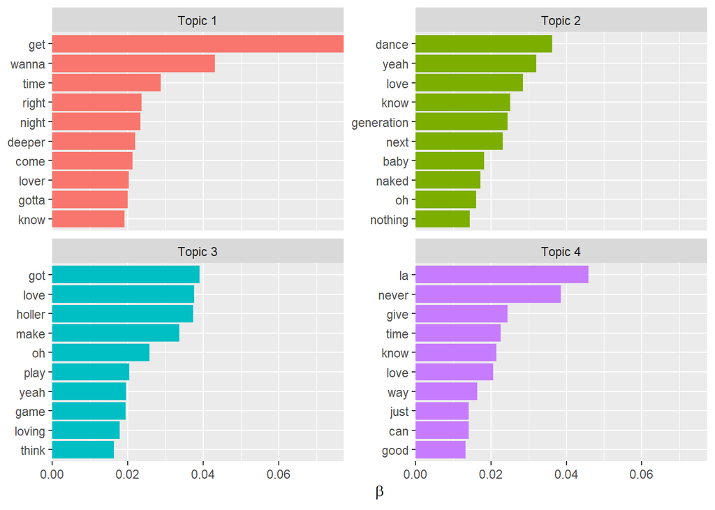

```r
word_topics %>%
  group_by(topic) %>%
  slice_max(beta, n = 10) %>%
  ungroup() %>%
  mutate(topic = paste("Topic", topic)) %>%
  ggplot(aes(beta, reorder_within(term, beta, topic), fill = topic)) +
  geom_col(show.legend = FALSE) +
  facet_wrap(vars(topic), scales = "free_y") +
  scale_x_continuous(expand = c(0, 0)) +
  scale_y_reordered() +
  labs(x = expression(beta), y = NULL) #Shows beta as a Greek symbo
```

I especially like the reorder_within() function which sorts the order along beta in each plot.

# **Interpretation: Song probabilities**

In the same way, probabilities of words given a topic can be extracted, the same can be done with the songs (=documents). This allows to inspect those songs that belong to topic. Again, the gamma value (similar to beta) can be interpreted as a kind of factor loading or salience parameter.

## Extracting song probabilities

```r
(song_topics <- tidy(topic_model, matrix = "gamma",
                    document_names = rownames(lyrics_sparse)) )
```

```
## # A tibble: 124 x 3
##    document                        topic    gamma
##    <chr>                           <int>    <dbl>
##  1 2 Become 1                          1 0.370
##  2 Denying                             1 0.00165
##  3 Do It                               1 0.994
##  4 Get Down With Me                    1 0.479
##  5 Goodbye                             1 0.000666
##  6 Holler                              1 0.00168
##  7 If U Can�t Dance                    1 0.000879
##  8 If You Wanna Have Some Fun          1 0.954
##  9 Last Time Lover                     1 0.997
## 10 Let Love Lead the Way               1 0.00149
## 11 Love Thing                          1 0.188
## 12 Mama                                1 0.00290
```

[output cut: 19 more lines]

## Plotting song assignments

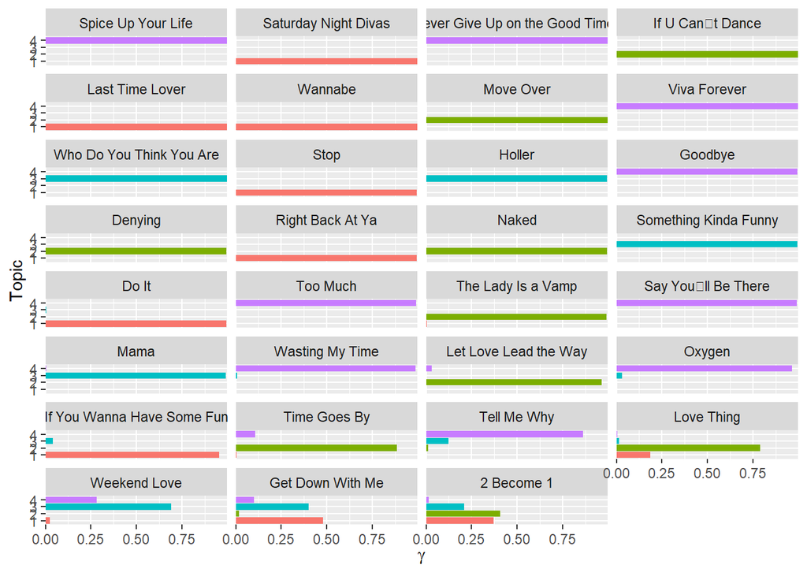

```r
song_topics %>%
  mutate(
    song_name = fct_reorder(document, gamma),
    topic = factor(topic)
  ) %>%
  ggplot(aes(gamma, topic, fill = topic)) +
  geom_col(show.legend = FALSE) +
  facet_wrap(vars(song_name), ncol = 4) +
  scale_x_continuous(expand = c(0, 0)) +
  labs(x = expression(gamma), y = "Topic")
```

Note: This is the same plot as in her Sherlock Holmes example (see https://juliasilge.com/blog/sherlock-holmes-stm/) but this time flipped to show the song names. The plot shows the uniqueness/non-overlap of the assignment of a song to the topic.

# **Adding predictors**

What I first found confusing is that she first extracts the topic and THEN adds predictors as I thought that adding predictors in the first step may support the extraction of meaningful topics (as it is possible when using the stm() function as shown in the vignette by Roberts et al. 2019). Below, however, I show that this is also possible in a tidy way.

The estimation of covariate (or better: predictor) effects is done via the estimateEffect function from the stm package.

```r
effects <-
  estimateEffect(
    1:4 ~ album_name, #The topics are regressed on the albums
    topic_model,
    tidy_lyrics %>% distinct(song_name, album_name) %>% arrange(song_name) #see comment below
  )

summary(effects)
```

```
##
## Call:
## estimateEffect(formula = 1:4 ~ album_name, stmobj = topic_model,
##     metadata = tidy_lyrics %>% distinct(song_name, album_name) %>%
##         arrange(song_name))
##
##
## Topic 1:
##
## Coefficients:
##                      Estimate Std. Error t value Pr(>|t|)
## (Intercept)           0.21970    0.13072   1.681    0.104
## album_nameSpice       0.04679    0.18936   0.247    0.807
## album_nameSpiceworld  0.07222    0.18657   0.387    0.702
##
##
## Topic 2:
##
## Coefficients:
##                      Estimate Std. Error t value Pr(>|t|)
## (Intercept)            0.1574     0.1321   1.191    0.244
## album_nameSpice        0.1510     0.1912   0.789    0.436
## album_nameSpiceworld   0.1374     0.1857   0.740    0.466
##
##
## Topic 3:
##
## Coefficients:
##                      Estimate Std. Error t value Pr(>|t|)
## (Intercept)           0.23183    0.11143   2.081   0.0467 *
## album_nameSpice       0.08604    0.15806   0.544   0.5905
## album_nameSpiceworld -0.21939    0.15581  -1.408   0.1701
## ---
## Signif. codes:  0 '***' 0.001 '**' 0.01 '*' 0.05 '.' 0.1 ' ' 1
##
##
## Topic 4:
##
## Coefficients:
##                       Estimate Std. Error t value Pr(>|t|)
## (Intercept)           0.391290   0.138792   2.819  0.00874 **
## album_nameSpice      -0.281995   0.196504  -1.435  0.16235
## album_nameSpiceworld  0.007429   0.192449   0.039  0.96948
## ---
## Signif. codes:  0 '***' 0.001 '**' 0.01 '*' 0.05 '.' 0.1 ' ' 1
```

Note. In the chunk, there is this line beginning with tidy_lyrics… The line looks complicated. Actually this refers to the “meta data” containing the importante predictors (in this case it is only the album name. This line intends to sort the song names in the same order as it is the case in the sparse matrix (lyrics_sparse) which is alphabetical. There is an early posting by Julia (https://github.com/juliasilge/tidytext/issues/114) in which she says that order is unimportant so I think that this is a false statement. Anyways, ordering does not harm.

Again, for clarification. Instead of pasting the pipeline in there in such a complicated way, she could have been able to create a separate data set. I present my own version below when I include the predictors from the start.

Note #2. When I run the code, I get an error message–but not in the video. Could be because that I was not able to get the cryptic characters out’.

The regression table can also be represented using broom’s tidy function:

```r
tidy(effects)
```

```
## # A tibble: 12 x 6
##    topic term                 estimate std.error statistic p.value
##    <int> <chr>                   <dbl>     <dbl>     <dbl>   <dbl>
##  1     1 (Intercept)           0.218       0.131    1.66   0.107
##  2     1 album_nameSpice       0.0469      0.189    0.248  0.806
##  3     1 album_nameSpiceworld  0.0729      0.189    0.387  0.702
##  4     2 (Intercept)           0.158       0.132    1.20   0.241
##  5     2 album_nameSpice       0.150       0.190    0.791  0.435
##  6     2 album_nameSpiceworld  0.139       0.186    0.748  0.461
##  7     3 (Intercept)           0.232       0.110    2.10   0.0445
##  8     3 album_nameSpice       0.0834      0.156    0.533  0.598
##  9     3 album_nameSpiceworld -0.221       0.154   -1.43   0.163
## 10     4 (Intercept)           0.390       0.138    2.82   0.00871
## 11     4 album_nameSpice      -0.282       0.191   -1.48   0.151
## 12     4 album_nameSpiceworld  0.00951     0.192    0.0496 0.961
```

The result shows that is there is no difference in the topics across albums.

# **Including predictors in the initial structual topic model**

The following code adapts Julia’s Jane-Austen example to the spice girl case. Reminder: The focal tibble is tidy_lyrics which contains the meta data and tokenized lyrics.

## Creating a separate meta data set with album name as the predictor

Note. This is an alternative (which I prefer) to adding the meta data as a pipeline within (as in the above estimateEffect example). Note the order of the song names (accoring to the order in lyric_sparse)

```r
(covariates_spice <- tidy_lyrics %>%
  distinct(song_name, album_name) %>%
  arrange(song_name) )
```

```
## # A tibble: 31 x 2
##    album_name song_name
##    <chr>      <chr>
##  1 Spice      2 Become 1
##  2 Spiceworld Denying
##  3 Spiceworld Do It
##  4 Forever    Get Down With Me
##  5 Forever    Goodbye
##  6 Forever    Holler
##  7 Spice      If U Can�t Dance
##  8 Forever    If You Wanna Have Some Fun
##  9 Spice      Last Time Lover
## 10 Forever    Let Love Lead the Way
## 11 Spice      Love Thing
## 12 Spice      Mama
```

[output cut: 19 more lines]

## Running the initial topic model (with fixed K) with predictors

```r
topic_model2 <- stm(lyrics_sparse,
                   K = 4,
                   prevalence = ~ album_name,
                   data = covariates_spice,
                   verbose = FALSE,
                   init.type = "Spectral")
summary(topic_model2)
```

```
## A topic model with 4 topics, 31 documents and a 979 word dictionary.
```

```
## Topic 1 Top Words:
##       Highest Prob: get, wanna, time, right, night, deeper, come
##       FREX: deeper, saturday, fun, comin, get, lover, night
##       Lift: breaking, freak, might, reasons, anybody, appetite, bass
##       Score: deeper, saturday, get, wanna, lover, comin, fun
## Topic 2 Top Words:
##       Highest Prob: dance, yeah, love, know, generation, next, baby
##       FREX: next, naked, denying, foolin, nobody, wants, meant
##       Lift: admit, bein, check, d'ya, defeat, else, everyone
##       Score: next, naked, dance, generation, denying, foolin, nobody
## Topic 3 Top Words:
##       Highest Prob: got, love, holler, make, oh, play, yeah
##       FREX: holler, kinda, swing, funny, yay, trust, loving
##       Lift: 2000, anyone, anything, bottom, driving, fantasy, follow
##       Score: holler, swing, kinda, funny, yay, loving, driving
## Topic 4 Top Words:
##       Highest Prob: la, never, give, time, know, love, way
##       FREX: times, swear, la, bring, promise, viva, tried
##       Lift: able, aggravation, angel, away, certain, dreamt, heaven
##       Score: la, times, aha, swear, chicas, front, havin
```

I inspected no real difference between this model and her initial model which may be due to the fact that the predictors had no predictive value. I don’t know yet whether this will be different when having highly predictve predictors.

## Estimating the effects again

```r
effects2 <-
  estimateEffect(
    1:4 ~ album_name,
    topic_model2,
    covariates_spice
  )
summary(effects2)
```

```
##
## Call:
## estimateEffect(formula = 1:4 ~ album_name, stmobj = topic_model2,
##     metadata = covariates_spice)
##
##
## Topic 1:
##
## Coefficients:
##                      Estimate Std. Error t value Pr(>|t|)
## (Intercept)           0.22703    0.13897   1.634    0.114
## album_nameSpice       0.04445    0.20177   0.220    0.827
## album_nameSpiceworld  0.08465    0.19432   0.436    0.666
##
##
## Topic 2:
##
## Coefficients:
##                      Estimate Std. Error t value Pr(>|t|)
## (Intercept)            0.1431     0.1356   1.055    0.301
## album_nameSpice        0.1538     0.1898   0.810    0.425
## album_nameSpiceworld   0.1419     0.1860   0.763    0.452
##
##
## Topic 3:
##
## Coefficients:
##                      Estimate Std. Error t value Pr(>|t|)
## (Intercept)            0.2287     0.1233   1.855   0.0741 .
## album_nameSpice        0.1020     0.1670   0.611   0.5464
## album_nameSpiceworld  -0.2244     0.1627  -1.379   0.1788
## ---
## Signif. codes:  0 '***' 0.001 '**' 0.01 '*' 0.05 '.' 0.1 ' ' 1
##
##
## Topic 4:
##
## Coefficients:
##                       Estimate Std. Error t value Pr(>|t|)
## (Intercept)           0.397692   0.135031   2.945  0.00643 **
## album_nameSpice      -0.293739   0.188857  -1.555  0.13109
## album_nameSpiceworld  0.004455   0.190409   0.023  0.98150
## ---
## Signif. codes:  0 '***' 0.001 '**' 0.01 '*' 0.05 '.' 0.1 ' ' 1
```

# **Estimating the topic model along a range of topics**

Instead of running the model with a fixed number of topics, running it across a range and inspecting some goodness of fit criteria may be the better option. In this case, I adapted Julia’s hacker corpus example (https://juliasilge.com/blog/evaluating-stm/) to the spice girls example.

```r
library(furrr)
plan(multicore)
```

*Note.* In the hacker corpus example, Julia used plan(multisession).

```r
many_models <- tibble(K = c(3, 4, 6, 7, 8)) %>%
  mutate(topic_model = future_map(
    K, ~stm(lyrics_sparse, K = ., verbose = FALSE), .options = furrr_options(seed = TRUE))
  )
```

*Note.* In Julia’s original example, she did not use the .options argument which resulted in a warning. Using this argument, however, is recommended as in this case, the algorithm generates L’Ecuyer-CMRG RNG seed random seed numbers (whatever this means ;)

Be that as it may, the central issue is that the above code generates a bunch of topic models (with the predescribed K’s) and stacks them into a nested tibble:

```r
many_models
```

```
## # A tibble: 5 x 2
##       K topic_model
##   <dbl> <list>
## 1     3 <STM>
## 2     4 <STM>
## 3     6 <STM>
## 4     7 <STM>
## 5     8 <STM>
```

## Creating evaluation criteria

In the next step, evaluation criteria are applied to (“mapped over”) the rows in the nested tibble:

```r
heldout <- make.heldout(lyrics_sparse)

k_result <- many_models %>%
  mutate(exclusivity        = map(topic_model, exclusivity),
         semantic_coherence = map(topic_model, semanticCoherence, lyrics_sparse),
         eval_heldout       = map(topic_model, eval.heldout, heldout$missing),
         residual           = map(topic_model, checkResiduals, lyrics_sparse),
         bound              = map_dbl(topic_model, function(x) max(x$convergence$bound)),
         lfact              = map_dbl(topic_model, function(x) lfactorial(x$settings$dim$K)),
         lbound             = bound + lfact,
         iterations         = map_dbl(topic_model, function(x) length(x$convergence$bound)))
```

## Plotting the four evaluation criteria

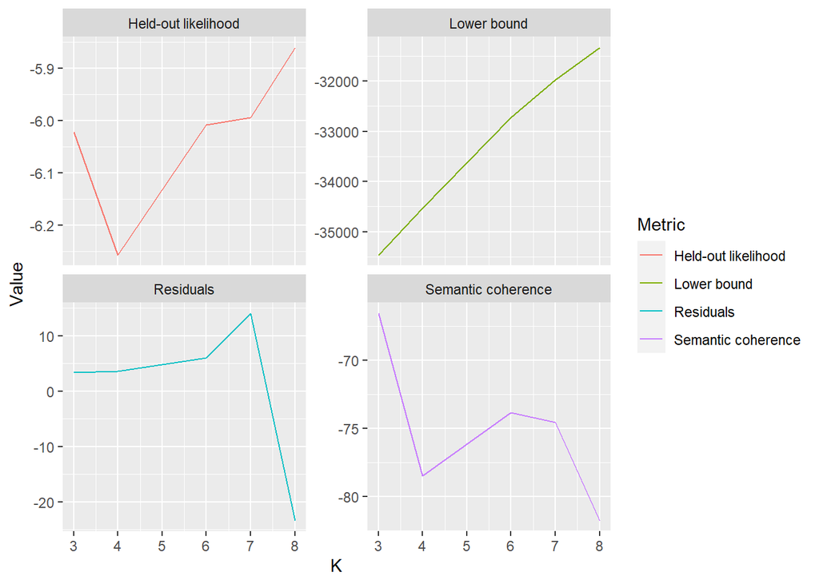

```r
k_result %>%
  transmute(K,
            `Lower bound`         = lbound,
            Residuals             = map_dbl(residual, "dispersion"),
            `Semantic coherence`  = map_dbl(semantic_coherence, mean),
            `Held-out likelihood` = map_dbl(eval_heldout, "expected.heldout")) %>%
  gather(Metric, Value, -K) %>%
  ggplot(aes(K, Value, color = Metric)) +
  geom_line() +
  facet_wrap(~Metric, scales = "free_y")
```

## Joint plotting of semantic coherence and exclusivity

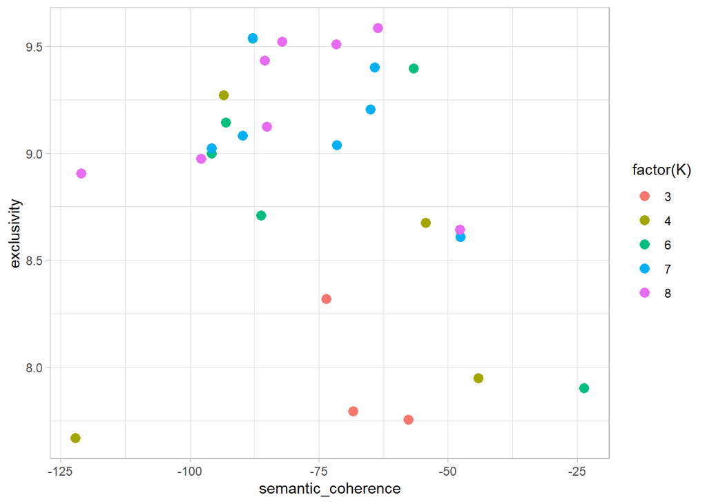

```r
k_result %>%
  select(K, exclusivity, semantic_coherence) %>%
  filter(K %in% c(3, 4,6,7, 8)) %>%
  unnest(cols = c(exclusivity, semantic_coherence)) %>%
  ggplot(aes(semantic_coherence, exclusivity,
             color = factor(K))) +
  geom_point(size=3, position = "jitter")+
  theme_light()
```

Overall, I have severe problems to interpret either of these plots. My first impression tended towards 8 topic but later I saw that this would lead to some topics being only occupied with 2 songs, which is very unattractive. So I stay with 4.

## Extracting the k=4 topic model

```r
topic_model <- k_result %>%
  filter(K == 4) %>%
  pull(topic_model) %>%
  .[[1]]
```

# **Exploring the content**

At this stage, exploring the word probabilities and song probabilities given the topics would be the natural thing to do as presented above. However, Julia draws another nice Joker and creates a plot that combines both (again, this originally stems from her hacker example):

```r
td_beta <- tidy(topic_model)

td_gamma <- tidy(topic_model, matrix = "gamma",
                 document_names = rownames(lyrics_sparse))
```

## Exploring the words and songs

The code contains 3 parts. The first creates the top words/terms for each topic. This is interesting in itself but only the first step to the final plot:

```r
(top_terms <- td_beta %>%
  arrange(beta) %>%
  group_by(topic) %>%
  top_n(6, beta) %>%
  arrange(-beta) %>%
  select(topic, term) %>%
  summarise(terms = list(term)) %>%
  mutate(terms = map(terms, paste, collapse = ", ")) %>%
  unnest(terms)  )
```

```
## # A tibble: 4 x 2
##   topic terms
##   <int> <chr>
## 1     1 get, wanna, time, right, night, deeper
## 2     2 dance, yeah, love, know, generation, next
## 3     3 got, love, holler, make, oh, play
## 4     4 la, never, give, time, know, love
```

Now, a tibble is created that conains the topic number, the 6 top terms extracted above and **the average gamma value** (i.e., the average connection between the top temrs and the topic). This average can be (this is my guess) interpreted similarly to the rsquare in a regression and describes how much the content of the topic is related to these 6 terms.

```r
gamma_terms <- td_gamma %>%
  group_by(topic) %>%
  summarise(gamma = mean(gamma)) %>%
  arrange(desc(gamma)) %>%
  left_join(top_terms, by = "topic") %>%
  mutate(topic = paste0("Topic ", topic),
         topic = reorder(topic, gamma))
```

## Plot

Note. Julia’s original plot resulted in some warnings in my case due to here use of some particular font data bases. I keep it simple and adapted the plot a bit (and excluded these fonts)

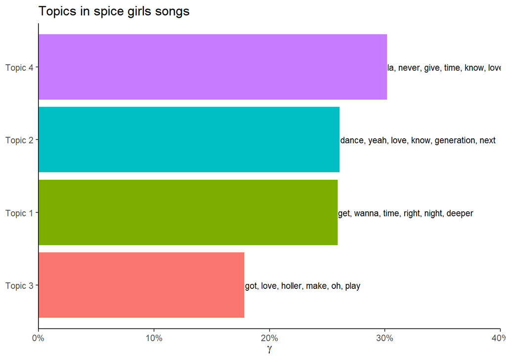

```r
library(ggthemes)

gamma_terms %>%
  top_n(20, gamma) %>%
  ggplot(aes(topic, gamma, label = terms, fill = topic)) +
  geom_col(show.legend = FALSE) +
  geom_text(hjust = 0, nudge_y = 0.0005, size = 3) +
  coord_flip() +
  scale_y_continuous(expand = c(0,0),
                     limits = c(0, 0.40),  #Das muss angepasst werden. Also bis hierhin laufen lassen
                     labels = scales::percent_format(accuracy=1.0)) +
  theme(plot.title = element_text(size = 16),
        plot.subtitle = element_text(size = 13)) +
  labs(x = NULL, y = expression(gamma),
       title = "Topics in spice girls songs")+
  theme_classic()
```

# **Some further exploration**

## How many songs belong to each topic?

```r
td_gamma %>%
  filter(gamma > .25) %>% #hier mal als threhold 25%
  count(topic, sort=TRUE)
```

```
## # A tibble: 4 x 2
##   topic     n
##   <int> <int>
## 1     4    10
## 2     1     9
## 3     2     9
## 4     3     6
```

## Which songs “belong” to each topic?

Note that a song has a probability to representing each topic. Hence, there must be some threshold. I choose .25

```r
td_gamma %>%
  filter(gamma > .25) %>%
  arrange(topic, -gamma) %>%
  mutate(gamma = round(gamma, 3))
```

```
## # A tibble: 34 x 3
##    document                        topic gamma
##    <chr>                           <int> <dbl>
##  1 Saturday Night Divas                1 0.998
##  2 Last Time Lover                     1 0.997
##  3 Wannabe                             1 0.997
##  4 Stop                                1 0.996
##  5 Right Back At Ya                    1 0.996
##  6 Do It                               1 0.994
##  7 If You Wanna Have Some Fun          1 0.954
##  8 Get Down With Me                    1 0.479
##  9 2 Become 1                          1 0.37
## 10 If U Can�t Dance                    2 0.997
## 11 Move Over                           2 0.997
## 12 Naked                               2 0.996
```

[output cut: 19 more lines]

## Depicting the 3 most salient songs for each topic (those with the highest gamma)

As some sources say (e.g. a video by Chris Bail, there is no way around to read the most salient documents to get a clue about the meaning of the topic.

```r
(salient_songs <- td_gamma %>%
  filter(gamma > .25) %>% #Schmeiß alle nter 25% Wahrscheinlichkeit raus
  arrange(topic, -gamma) %>%
  group_by(topic) %>%
  top_n(3) %>%
  mutate(gamma = round(gamma, 3)) %>%
  select(topic, document, gamma) )
```

```
## # A tibble: 12 x 3
## # Groups:   topic [4]
##    topic document                        gamma
##    <int> <chr>                           <dbl>
##  1     1 Saturday Night Divas            0.998
##  2     1 Last Time Lover                 0.997
##  3     1 Wannabe                         0.997
##  4     2 If U Can�t Dance                0.997
##  5     2 Move Over                       0.997
##  6     2 Naked                           0.996
##  7     3 Who Do You Think You Are        0.997
##  8     3 Holler                          0.996
##  9     3 Something Kinda Funny           0.995
## 10     4 Spice Up Your Life              0.998
## 11     4 Never Give Up on the Good Times 0.998
## 12     4 Viva Forever                    0.997
```

## Extracting the lyrics of these top songs

I guess there is a better way to do this and it depends on how the original corpus looks like

```r
salient_songs %>%
  ungroup() %>%
  select(song_name = document, topic) %>%
  left_join(lyrics, by ="song_name") %>%
  select(topic, song_name, line) %>%
  filter(song_name =="Wannabe") %>%
  select(line) %>%
  print(n=100)
```

```
## # A tibble: 60 x 1
##    line
##    <chr>
##  1 "Hahaha"
##  2 "Yo, I'll tell you what I want, what I really, really want"
##  3 "So tell me what you want, what you really, really want"
##  4 "I'll tell you what I want, what I really, really want"
##  5 "So tell me what you want, what you really, really want"
##  6 "I wanna (Hey!), I wanna (Hey!), I wanna (Hey!), I wanna (Hey!)"
##  7 "I wanna really, really, really wanna \"zig-a-zig\", ah"
##  8 "If you want my future, forget my past"
##  9 "If you wanna get with me, better make it fast"
## 10 "Now don't go wasting my precious time"
## 11 "Get your act together, we could be just fine"
## 12 "I'll tell you what I want, what I really, really want"
```

[output cut: 48 more lines]

“zig-a-zig”, ah”….

# Topic correlations

As topic models are mixture models and each topic has a “value” (=gamma) on all topics, the topics may be unrelated or correlated. A positive correlation may indicate that documents having content about topic A tend also to present some content of topic B and a negative correlation may indicate that documents presenting topic A sytematically not represent topic B. The more the topic are excusive/non-overlapping, the more the correlations will strive towards -1.

In a video by Oskar Enghoff (https://www.youtube.com/watch?v=IC5BWQrCNUM&ab_channel=methodsMcr), he showed at 34:38 how to generate a topic correlation matrix and a network of correlating topics.

```r
KM <- stm::topicCorr(topic_model)$cor %>%
  as_tibble() %>%
  mutate(across(everything(), round, 2)) %>%
  as.matrix()
rownames(KM) = c("topic1","topic2", "topic3", "topic4")
colnames(KM) = c("topic1","topic2", "topic3", "topic4")
KM
```

```
##        topic1 topic2 topic3 topic4
## topic1   1.00  -0.33  -0.25  -0.42
## topic2  -0.33   1.00  -0.30  -0.40
## topic3  -0.25  -0.30   1.00  -0.27
## topic4  -0.42  -0.40  -0.27   1.00
```

In his video, Oskar also presented a nice network however, seeing the code was not possible. I try to mimic this with the qgraph package:

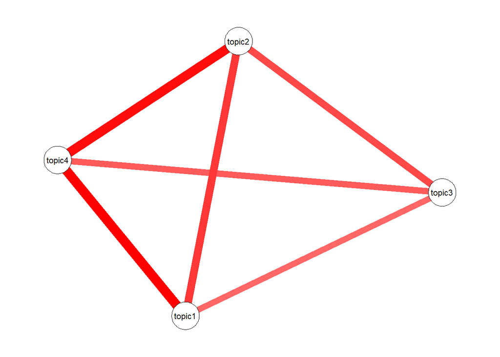

```r
library(qgraph)
Q <- qgraph(KM,
      layout = "spring",
      diag = FALSE,
      labels = colnames(KM),
      edge.color = "red",
      legend.cex = 1,
      vsize = 6,
      label.cex = 1,
      label.color = "black")
```

Another option would be to plot the correlation matrix. In this case, this looks not very interesting but that may be different when having more topics with a more diverse correlation pattern. I can imagin adding document level outcomes and estimating a regression model with the topics as predictors…

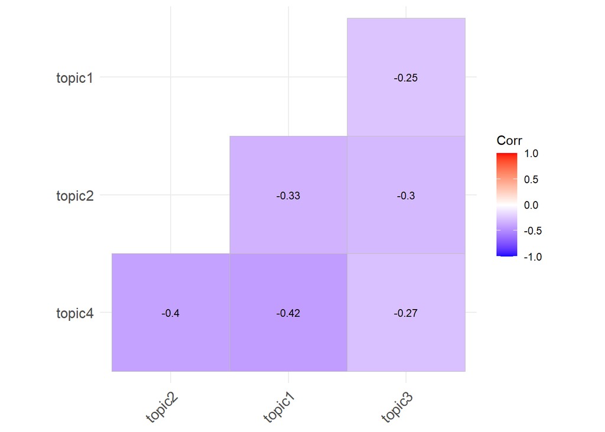

```r
library(ggcorrplot)
ggcorrplot(KM,
           type = "lower",
           show.diag = FALSE,
           hc.order = TRUE,
           lab = TRUE,
           lab_size = 3   )
```